# Extensão e Sociologia Rural

Desenvolvimento do Capitalismo no Campo  
Modernização da Agricultura

Luiz Diego Vidal Santos

## Visão Geral

### Tópicos Principais

- 1 Postulados de Marx e o Campo
- 2 Formas do Capitalismo no Campo
- 3 Revolução Verde
- 4 Extensão Rural como Ferramenta
- 5 Capital Estrangeiro e Consequências

**Objetivo Central**

Compreender o desenvolvimento do capitalismo no campo brasileiro, desde a modernização agrícola até os impactos do capital estrangeiro na estrutura agrária.

## O CAPITALISMO - POSTULADOS DE MARX

A compreensão do capitalismo a partir de Karl Marx pode ser entendida como:

1. A **exploração da mais-valia** pelos donos dos meios de produção
2. A **objetificação** de tudo para posterior comercialização
3. **Lucro** pela exploração e especulação do produto

**Schneider (2003):** os debates sobre o capitalismo e sua atuação no campo sempre estiveram focados no envolvimento do campo frente ao **crescimento econômico** e sua exploração.

> O meio rural quase nunca se beneficiou do capitalismo em sua essência (Martins, 2008).

## MEIO RURAL - CONCEITO

**Angela Kageyama (2008):**

- Espaço com maior presença de **áreas verdes ou naturais**
- Grandes distâncias entre residências e comércios
- Forte dependência de **recursos naturais** (água e terra)
- Representações **culturais e simbólicas** da ruralidade

O campo, mesmo próximo do urbano (*rurbano*), ainda apresenta **características exclusivas** que representam a atuação diferente do capitalismo para com seus residentes e trabalhadores.

## CAPITALISMO NO CAMPO - DEBATE

A partir da **década de 1920**, o debate se concentrou na **persistência** das unidades agrícolas familiares.

**Ricardo Abramovay** (Paradigmas do Capitalismo Agrário em Questão, 2007):

> A agricultura de base familiar ainda luta pela sua continuidade, sob constante expansão do sistema intensivo subvencionado pelo **capital financeiro especulativo**.

## FORMAS DO CAPITALISMO NO CAMPO

| Forma | Descrição |
| --- | --- |
| **Latifúndio** | Concentração de grandes extensões de terra em poucos proprietários |
| **Agronegócio** | Integração agricultura + indústria + mercado globalizado; commodities em larga escala |
| **Agroindústria** | Transformação de produtos agrícolas (alimentos processados, biocombustíveis, cosméticos) |

**Resistência:**

- Movimentos sociais rurais (ligas camponesas, MST)
- Populações tradicionais (indígenas, quilombolas, ribeirinhos)

## REVOLUÇÃO VERDE

[figure not shown]

Mapa MATOPIBA - áreas legalmente atribuídas: UC, TI, assentamentos, quilombos (CC-BY-SA 4.0, Embrapa/Wikimedia)

**Definição:** conjunto de mudanças técnicas na produção agrícola que configuram a articulação entre **agricultura e indústria**.

**Objetivos:**

- Implantar um **pacote tecnológico** na agricultura mundial
- Descartando as ruralidades existentes e suas peculiaridades

**Consequências:**

- Estatização das agendas **industrializantes neoliberais**
- Direcionamento aos interesses de **multinacionais**
- Consequências que perduram até hoje (Schneider, 2010)

## EXTENSÃO E ATER COMO FERRAMENTA

As atividades iniciais das agências extensionistas serviram ao capitalismo:

- **AIA** (Agência Americana) - promoção de métodos industrializantes (Peixoto, 2008)
- **EMBRATER** - Lei 6.126/74: extensão rural estatizada no Brasil

**Objetivo:** divulgação e incentivo de produtos próprios usando **técnicas difusionistas**.

A **Embrapa** aprimorou e potencializou a agropecuária brasileira, mas os resultados foram **assimétricos**.

## CONSEQUÊNCIAS DA MODERNIZAÇÃO

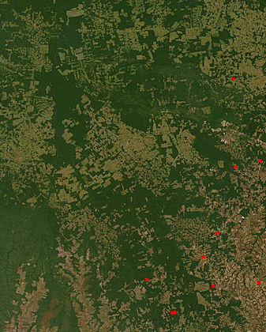

Desmatamento no Mato Grosso - imagem de satélite NASA FIRMS (domínio público)

**Lado positivo:**

- Decisivas na **balança comercial** brasileira
- Sucessivos **superávits**

**Lado negativo:**

- Danos ambientais **irreparáveis**
- Reafirmação do caráter **concentrador** do desenvolvimento
- Exclusão social dos pequenos produtores

## CAPITAL ESTRANGEIRO

A aquisição de terras por capital estrangeiro impacta significativamente:

**Efeitos positivos:**

- Distribuição de renda por trabalhadores (poucos e sazonais)

**Efeitos negativos:**

- Quase nenhum **benefício social** - empresas rurais são as que menos tributam
- **Oligopolização** do sistema de produção
- Impacto na **segurança alimentar** - terras destinadas a commodities para exportação
- **Especulação imobiliária** dos ativos: água, clima tropical, terras produtivas

## CONFLITOS AGRÁRIOS CONTEMPORÂNEOS

### Dimensões dos Conflitos

O campo brasileiro contemporâneo permanece como palco de **conflitos estruturais** que evidenciam as contradições do modelo capitalista agrário (CPT, 2023):

- Disputa por **terras devolutas e públicas** entre grileiros e comunidades tradicionais
- **Envenenamento de águas** por agrotóxicos em áreas limítrofes a monoculturas
- Assassinato de lideranças rurais e ambientalistas
- Expansão da soja e pecuária sobre **terras indígenas e quilombolas**

### Dados Recentes (CPT, 2023)

A Comissão Pastoral da Terra registrou em 2022:

- **1.893 conflitos por terra** no Brasil
- **47 assassinatos** de trabalhadores rurais e lideranças
- Aumento de **grilagem digital** via CAR fraudulento
- Crescimento de conflitos hídricos no Nordeste e Centro-Oeste

> O capitalismo no campo não eliminou os conflitos agrários - **aprofundou-os** sob novas formas.

## CONCLUSÃO

O desenvolvimento do capitalismo e a modernização da agricultura no Brasil é um tema **multifacetado** que se entrelaça com a história, a política, a economia e a sociologia.

Envolve uma busca por um desenvolvimento rural **sustentável** que englobe:

- Dimensões **econômicas, sociais e ambientais**
- Relação com a **agricultura familiar**
- **Liberdade** e autonomia dos sujeitos do campo

## REFERÊNCIAS

- Abramovay, R. Paradigmas do capitalismo agrário em questão (2007)
- Alves, P. D. Políticas Agrícolas para agricultura familiar (2012)
- Brasil. Lei 5.969/73 - PROAGRO (1973)
- Kageyama, A. A. Desenvolvimento rural (2008)
- Martins, J. S. A sociabilidade do homem simples (2008)
- Navarro, Z. Desenvolvimento rural no Brasil (2001)
- Schneider, S. Situando o desenvolvimento rural no Brasil (2010)
- Veiga, J. E. Desenvolvimento sustentável (2010)

Obrigado!

Luiz Diego Vidal Santos

Universidade Federal de Sergipe (UFS)